# hw1

2022-04-01

#Question 1: Define supervised and unsupervised learning. What are the difference(s) between them?

**In supervised learning, input data is provided to the model along with the output.** **In unsupervised learning, only input data is provided to the model.**

#Question 2: Explain the difference between a regression model and a classification model, specifically in the context of machine learning.

**Regression helps predict a continuous quantity (Y is quantitative)**

**Classification predicts discrete class labels, Categorical values (Y is qualitative)**

#Question 3: Name two commonly used metrics for regression ML problems. Name two commonly used metrics for classification ML problems.

**Regression model: Mean Squared Error (MSE). Root Mean Squared Error (RMSE).** **classification model :confusion matrix, log-loss**

#Question 4: As discussed, statistical models can be used for different purposes. These purposes can generally be classified into the following three categories. Provide a brief description of each.

**Descriptive models:Choose model to best visually emphasize a trend in data i.e., using a line on a scatterplot**

**Inferential models:Aim is to test theories (Possibly) causal claims State relationship between outcome & predictor(s)**

**Predictive models:Aim is to predict Y with minimum reducible error Not focused on hypothesis tests (Lecture note day2)**

#Question 5: Predictive models are frequently used in machine learning, and they can usually be described as either mechanistic or empirically-driven. Answer the following questions.

Define mechanistic. Define empirically-driven. How do these model types differ? How are they similar?

**Mechanistic: Assume a parametric form for f ;Won’t match true unknown f ;Can add parameters =more flexibility ;Too many = overfitting** **empirically-driven: No assumptions about f;Require a larger number of observations; Much more flexible by default; Overfitting** In general, is a mechanistic or empirically-driven model easier to understand? Explain your choice. **For me mechanistic model is more understandable, we can use theory to make a prediction if society has lots of information about that event.**

Describe how the bias-variance tradeoff is related to the use of mechanistic or empirically-driven models.

#Question 6: A political candidate’s campaign has collected some detailed voter history data from their constituents. The campaign is interested in two questions:

Given a voter’s profile/data, how likely is it that they will vote in favor of the candidate?

How would a voter’s likelihood of support for the candidate change if they had personal contact with the candidate?

Classify each question as either predictive or inferential. Explain your reasoning for each.

**For the first question, it is predictive, which the response can be probablity.**

**For the second question, it is is inferential, the response will contain relationship between outcome and predictors.**

Exercise 1: We are interested in highway miles per gallon, or the hwy variable. Create a histogram of this variable. Describe what you see/learn.

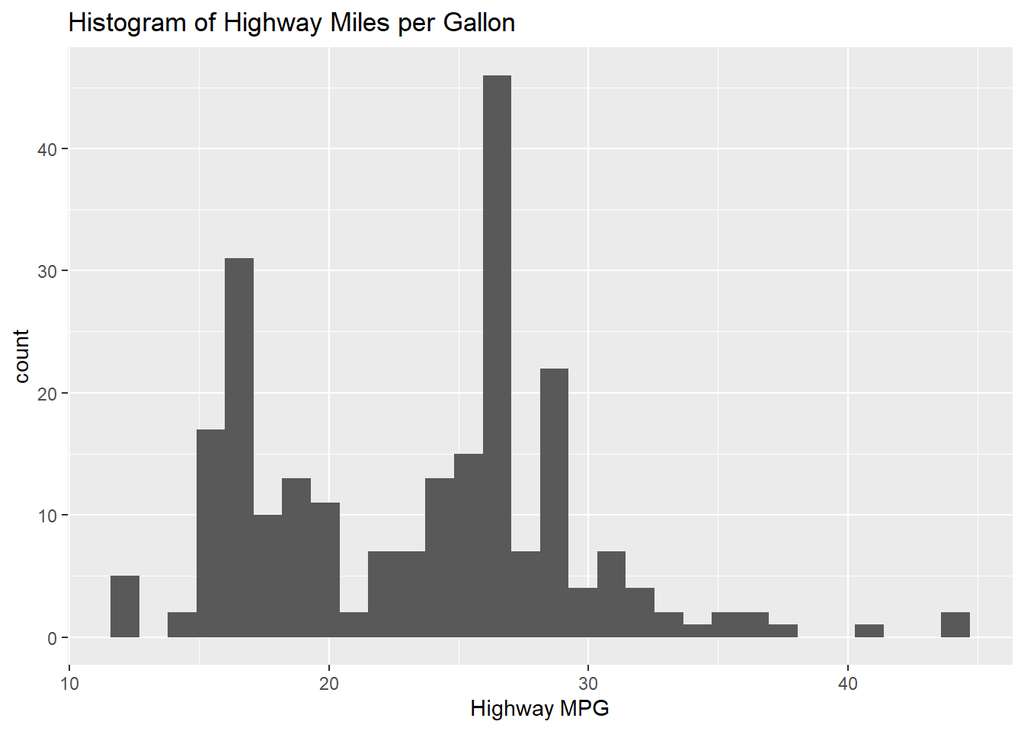

```r
ggplot(mpg, aes(x=hwy)) + geom_histogram()+
labs(x="Highway MPG", title="Histogram of Highway Miles per Gallon")
```

**“Highway Miles per Gallon” is plotted on the x-axis and its count is plotted on the y-axis. 25-30 Gallon has the highest count, and and most of the highway miles per gallon is in 15-30Gallon**

Exercise 2: Create a scatterplot. Put hwy on the x-axis and cty on the y-axis. Describe what you notice. Is there a relationship between hwy and cty? What does this mean?

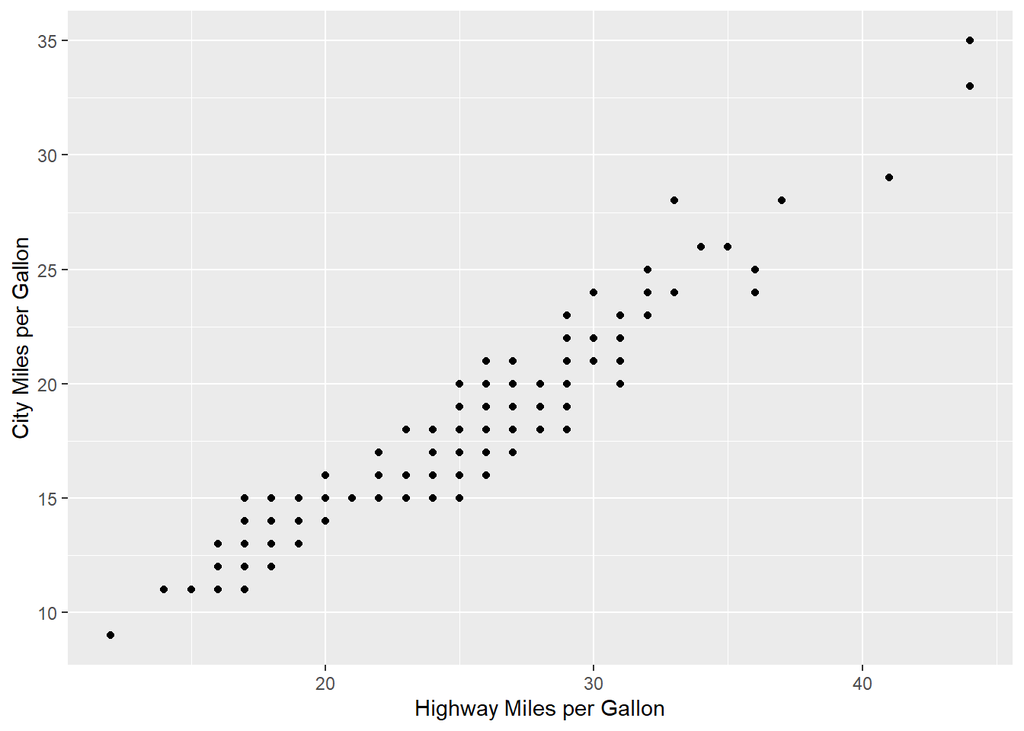

```r
 ggplot(mpg, aes(hwy, cty)) +geom_point() +
labs(x="Highway Miles per Gallon", y="City Miles per Gallon")
```

**From the graph above, we can tell there is a positive correlation between City Miles per Gallon and Highway Miles per Gallon. As Highway Miles per Gallon increase, City Miles per Gallon will also increase.**

Exercise 3: Make a bar plot of manufacturer. Flip it so that the manufacturers are on the y-axis. Order the bars by height. Which manufacturer produced the most cars? Which produced the least?

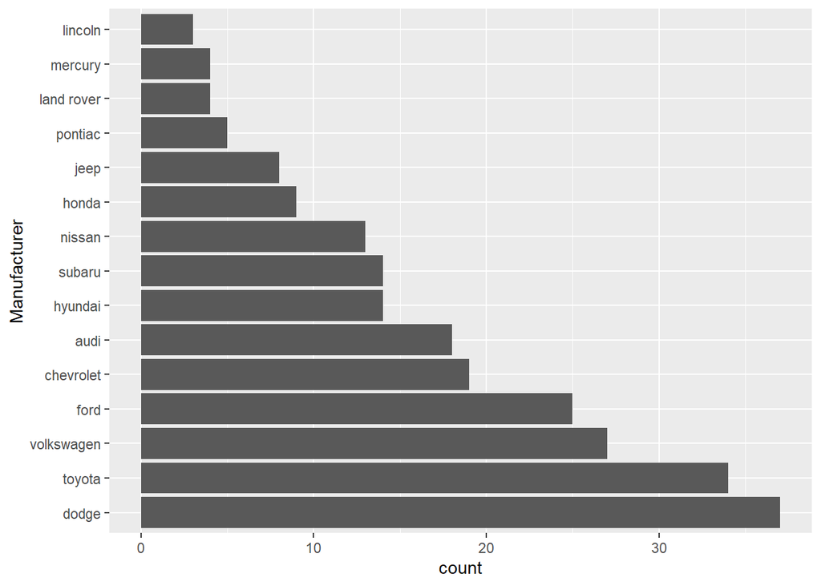

```r
ggplot(mpg, aes(x=reorder(manufacturer,rep(-1,length(manufacturer)),sum))) + geom_bar()+ coord_flip()+labs(x="Manufacturer")
```

**we can tell that Dodge produced the most and Lincoln produced the least.**

Exercise 4: Make a box plot of hwy, grouped by cyl. Do you see a pattern? If so, what?

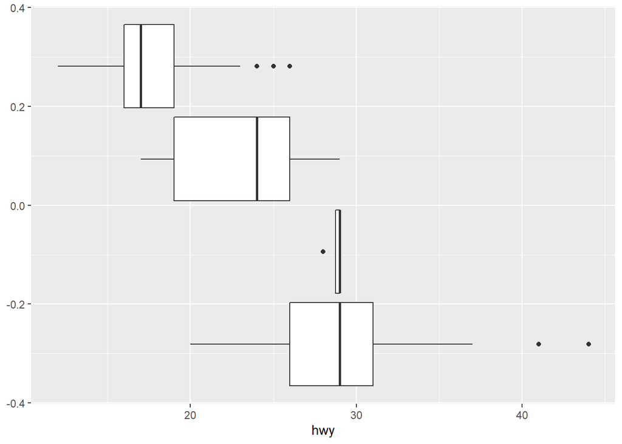

```r
ggplot(mpg,aes(group = cyl, x=hwy))+geom_boxplot()
```

**we can tell a pattern of the more cylinders a car have, the less highway miles per gallon this car may have.**

Exercise 5: Use the corrplot package to make a lower triangle correlation matrix of the mpg dataset. (Hint: You can find information on the package here.) Which variables are positively or negatively correlated with which others? Do these relationships make sense to you? Are there any that surprise you?

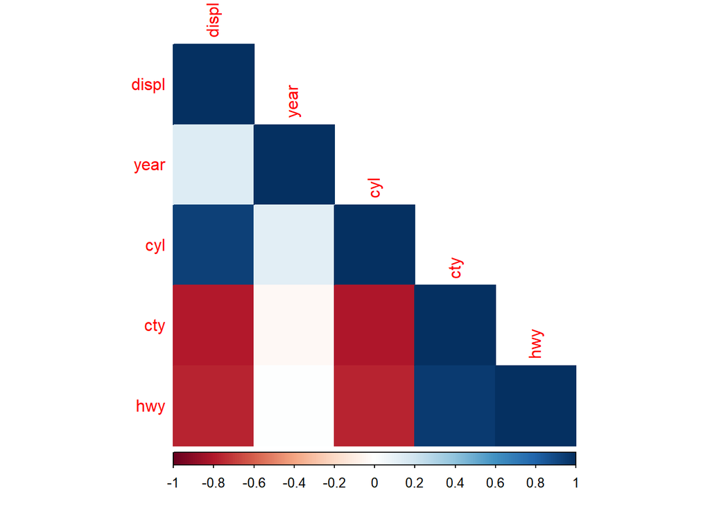

```r
M = cor(mpg %>% dplyr::select(where(is.numeric)))
corrplot(M,method = 'color',type = 'lower')
```

Negative Correlations disp~cty disp~hwy cyl~cty cyl~hwy Positive Correlations: disp~cyl cty~hwy